# Assignment_5

2024-04-05

## Library and data

```r
set.seed(123)
library(stats)
library(cluster)
library(dplyr)
library(caret)
library(NbClust)
library(factoextra)
library(tibble)


df_1 <- read.csv("C:/Users/John/Documents/Cereals.csv")
df_1 <- na.omit(df_1)
rownames(df_1) <- df_1$name
df_1 <- df_1[, -c(1:3)]
head(df_1)
```

```
##                           calories protein fat sodium fiber carbo sugars potass
## 100%_Bran                       70       4   1    130  10.0   5.0      6    280
## 100%_Natural_Bran              120       3   5     15   2.0   8.0      8    135
## All-Bran                        70       4   1    260   9.0   7.0      5    320
## All-Bran_with_Extra_Fiber       50       4   0    140  14.0   8.0      0    330
## Apple_Cinnamon_Cheerios        110       2   2    180   1.5  10.5     10     70
## Apple_Jacks                    110       2   0    125   1.0  11.0     14     30
##                           vitamins shelf weight cups   rating
## 100%_Bran                       25     3      1 0.33 68.40297
## 100%_Natural_Bran                0     3      1 1.00 33.98368
## All-Bran                        25     3      1 0.33 59.42551
## All-Bran_with_Extra_Fiber       25     3      1 0.50 93.70491
## Apple_Cinnamon_Cheerios         25     1      1 0.75 29.50954
## Apple_Jacks                     25     2      1 1.00 33.17409
```

## Normalization

```r
df <- scale(df_1)
head(df)
```

```
##                             calories    protein        fat     sodium
## 100%_Bran                 -1.8659155  1.3817478  0.0000000 -0.3910227
## 100%_Natural_Bran          0.6537514  0.4522084  3.9728810 -1.7804186
## All-Bran                  -1.8659155  1.3817478  0.0000000  1.1795987
## All-Bran_with_Extra_Fiber -2.8737823  1.3817478 -0.9932203 -0.2702057
## Apple_Cinnamon_Cheerios    0.1498180 -0.4773310  0.9932203  0.2130625
## Apple_Jacks                0.1498180 -0.4773310 -0.9932203 -0.4514312
##                                 fiber      carbo     sugars     potass
## 100%_Bran                  3.22866747 -2.5001396 -0.2542051  2.5605229
## 100%_Natural_Bran         -0.07249167 -1.7292632  0.2046041  0.5147738
## All-Bran                   2.81602258 -1.9862220 -0.4836096  3.1248675
## All-Bran_with_Extra_Fiber  4.87924705 -1.7292632 -1.6306324  3.2659536
## Apple_Cinnamon_Cheerios   -0.27881412 -1.0868662  0.6634132 -0.4022862
## Apple_Jacks               -0.48513656 -0.9583868  1.5810314 -0.9666308
##                             vitamins      shelf     weight       cups
## 100%_Bran                 -0.1818422  0.9419715 -0.2008324 -2.0856582
## 100%_Natural_Bran         -1.3032024  0.9419715 -0.2008324  0.7567534
## All-Bran                  -0.1818422  0.9419715 -0.2008324 -2.0856582
## All-Bran_with_Extra_Fiber -0.1818422  0.9419715 -0.2008324 -1.3644493
## Apple_Cinnamon_Cheerios   -0.1818422 -1.4616799 -0.2008324 -0.3038480
## Apple_Jacks               -0.1818422 -0.2598542 -0.2008324  0.7567534
##                               rating
## 100%_Bran                  1.8549038
## 100%_Natural_Bran         -0.5977113
## All-Bran                   1.2151965
## All-Bran_with_Extra_Fiber  3.6578436
## Apple_Cinnamon_Cheerios   -0.9165248
## Apple_Jacks               -0.6553998
```

## Apply hierarchical clustering to the data using Euclidean distance to the normalized

measurements. Use Agnes to compare the clustering from single linkage, complete linkage, average linkage, and Ward. Choose the best method.

```r
hc_single <- agnes(df, method = "single")
hc_complete <- agnes(df, method = "complete")
hc_average <- agnes(df, method = "average")
hc_ward <- agnes(df, method = "ward")

print(hc_single$ac) # single
```

```
## [1] 0.6067859
```

```r
print(hc_complete$ac)
```

```
## [1] 0.8353712
```

```r
print(hc_average$ac)
```

```
## [1] 0.7766075
```

```r
print(hc_ward$ac)
```

```
## [1] 0.9046042
```

Ward is the optimal method because it has the largest agglomerative coefficient.

## How many clusters would you choose?

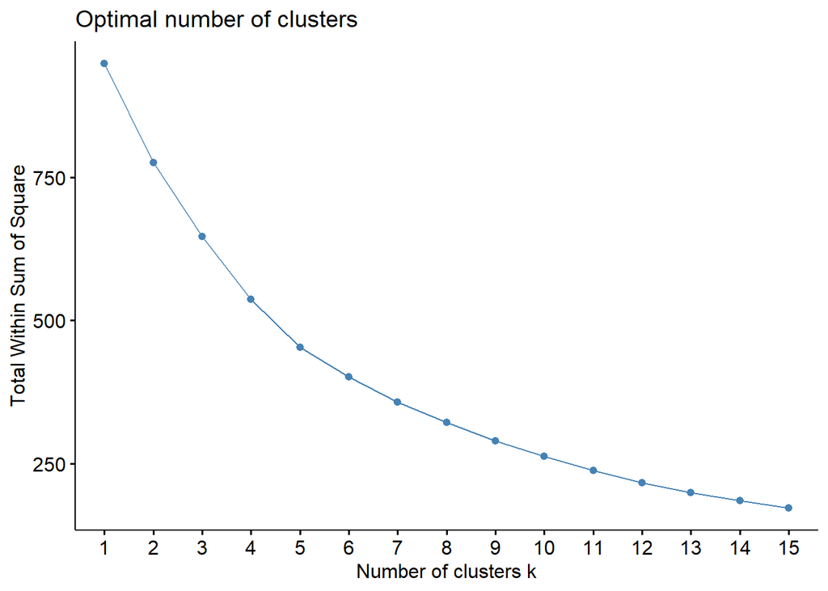

```r
fviz_nbclust(df, FUNcluster = hcut, method = "wss", k.max = 15)
```

There is no obvious elbow but k=5 seems to offer the best clusters.

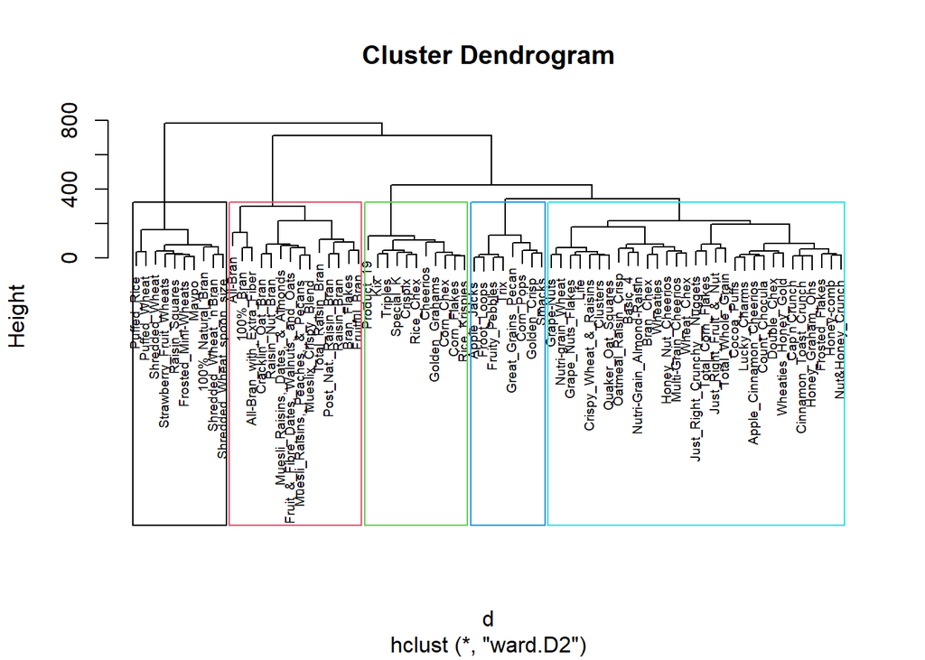

```r
d <- dist(df_1, method = "euclidean")
hc_ward <- hclust(d, method = "ward.D2")

plot(hc_ward, cex = 0.6)
rect.hclust(hc_ward, k = 5, border = 1:6)
```

## Comment on the structure of the clusters and on their stability. Hint: To check stability,

partition the data and see how well clusters formed based on one part apply to the other part.

```r
set.seed(123)
partitions <- createDataPartition(df[,"calories"], p=0.5, list=FALSE)

A <- df[partitions, ]
B <- df[-partitions, ]

nrow(A)
```

```
## [1] 37
```

```r
nrow(B)
```

```
## [1] 37
```

We created two equal partitions

```r
hc_ward_A <- agnes(A, method = "ward")
hc_ward_B <- agnes(B, method = "ward")

hc_ward_A$ac
```

```
## [1] 0.8271325
```

```r
hc_ward_B$ac
```

```
## [1] 0.8391847
```

```r
sum(kmeans(A, centers = 2)$withinss)
```

```
## [1] 385.2337
```

```r
sum(kmeans(B, centers = 2)$withinss)
```

```
## [1] 381.6136
```

The two partitions have very similar agglomerative coefficients of .83 and .84. Additionally they have very similar WCSS.

##The elementary public schools would like to choose a set of cereals to include in their daily cafeterias. Every day a different cereal is offered, but all cereals should support a healthy diet. For this goal, you are requested to find a cluster of “healthy cereals.” Should the data be normalized? If not, how should they be used in the cluster analysis?

The data shouldn’t be normalized because each of the nutrition facts need to be interpretable to make decisions regarding healthiness. For example, sodium is vital for humans but too much can have negative health effects.

```r
cut_hc_ward <- cutree(hc_ward, k = 5)


Clust_1 <- df_1 %>%
  filter(cut_hc_ward == 1) %>%
  summarize_all(median)

Clust_2 <- df_1 %>%
  filter(cut_hc_ward == 2) %>%
  summarize_all(median)

Clust_3 <- df_1 %>%
  filter(cut_hc_ward == 3) %>%
  summarize_all(median)

Clust_4 <- df_1 %>%
  filter(cut_hc_ward == 4) %>%
  summarize_all(median)

Clust_5 <- df_1 %>%
  filter(cut_hc_ward == 5) %>%
  summarize_all(median)


combined_clust <- bind_rows(Clust_1 %>% mutate(cluster = 1),
                              Clust_2 %>% mutate(cluster = 2),
                              Clust_3 %>% mutate(cluster = 3),
                              Clust_4 %>% mutate(cluster = 4),
                              Clust_5 %>% mutate(cluster = 5)) %>%
                              rownames_to_column(var = "cluster_name")

combined_clust
```

```
##   cluster_name calories protein fat sodium fiber carbo sugars potass vitamins
## 1            1      120     3.0   1  155.0   5.0  12.5   10.5  195.0       25
## 2            2       90     2.5   0    0.0   2.5  15.0    1.5   97.5        0
## 3            3      110     2.0   1  190.0   1.5  15.0    8.0   90.0       25
## 4            4      110     2.0   1  107.5   1.0  12.0   12.5   30.0       25
## 5            5      110     2.0   0  280.0   0.0  21.0    3.0   40.0       25
##   shelf weight cups   rating cluster
## 1     3      1 0.67 40.07609       1
## 2     2      1 1.00 60.06005       2
## 3     2      1 0.75 36.52368       3
## 4     2      1 0.94 32.69084       4
## 5     1      1 1.00 41.50354       5
```

Here we found the median of each variable for each cluster. This will allow use to compare each cluster. Cluster 1 ranks high on average in protein, fiber, potassium, vitamins, shelf stability, and maintains a respectable rating. I believe this makes the cereals in cluster 1 a great choice for the school.